# Analyzing Individual BGG Users

Phil Henrickson

2022-01-02

# **PSwayze12’s** BoardGameGeek Collection

This notebook contains a set of analyses for the selected user’s boardgamegeek collection. The bulk of the analysis is focused on building a user-specific predictive model to predict the games that PSwayze12 is likely to own. This enables to ask questions like, based on the games the user currently owns, what games are a good fit for their collection? What upcoming games are they likely to purchase?

This analysis is based on data from BoardGameGeek that was last updated on **2021-12-20.**

# 1 Collection Overview

We can look at a basic description of the number of games that the user owns, has rated, has previously owned, etc.

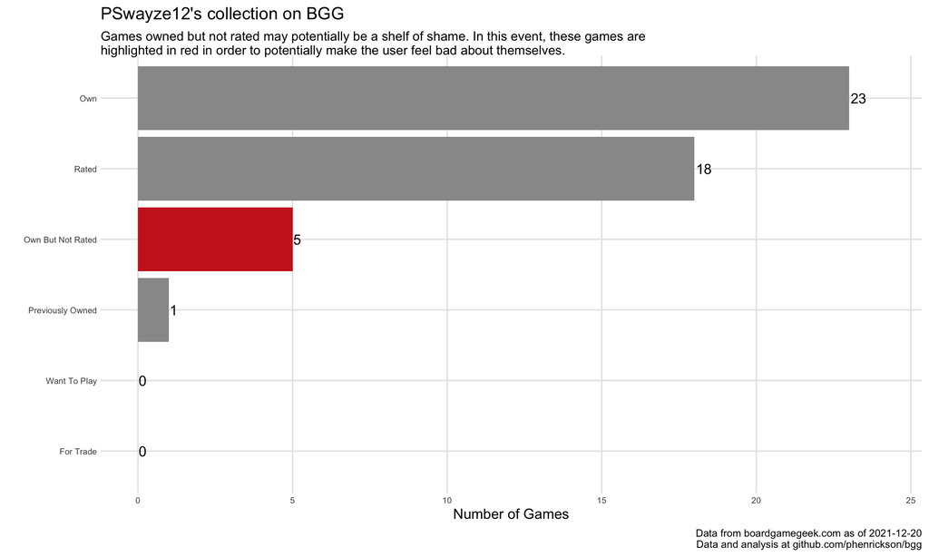

What years has the user owned/rated games from? While we can’t see when a user added or removed a game from their collection, we can look at their collection by the years in which their games were published.

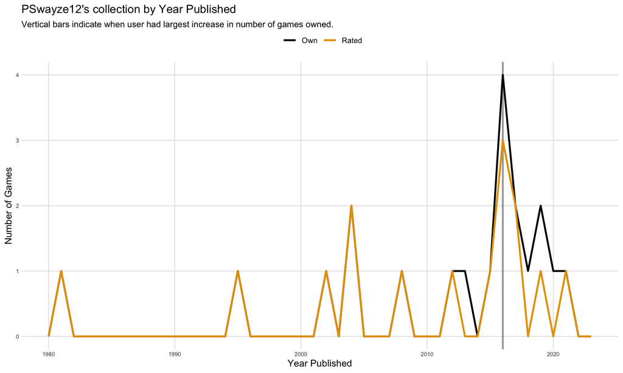

## 1.1 What types of games does PSwayze12 own?

We can look at the most frequent types of categories, mechanics, designers, and artists that appear in a user’s collection.

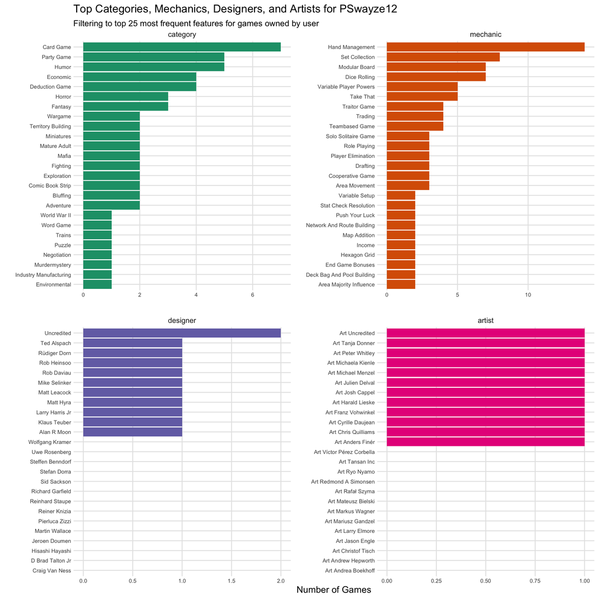

# 2 Modeling **PSwayze12’s** Collection

| username | dataset | period | games_owned | games_rated | games_played |
| --- | --- | --- | --- | --- | --- |
| PSwayze12 | training | published before 2020 | 21 | 17 | 22 |
| PSwayze12 | test | published 2020 or later | 2 | 1 | 2 |

There are two main (binary) outcomes we will be modeling for the user.

The first, **own** refers to whether the user currently lists a game as owned in their collection. The second, **played** refers to whether the user currently owns, has rated, or previously owned a game. This means the latter will generally have a larger list of games, but may still be a useful category to examine for people who play lots of games without necessarily owning them.

We will train predictive models to learn the probability that the user will own or play individual games based on their features.

## 2.1 Coefficients for PSwayze12

We can examine coefficients from the trained modes, which are penalized logistic regressions fit to our two main outcomes. Positive values indicate that a feature increases a user’s probabilility of owning/rating a game, while negative values indicate a feature decreases the probability.

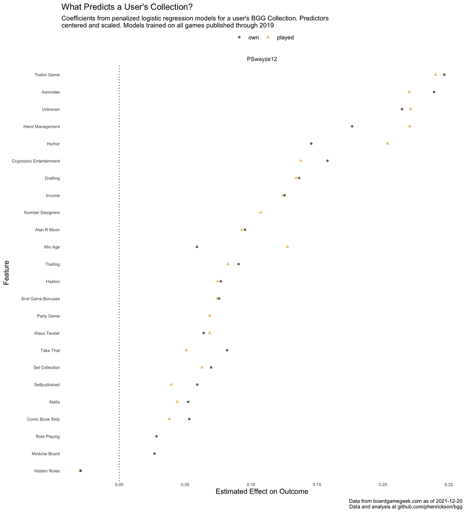

## 2.2 Visualizing Predictors for PSwayze12’s Collection

Why did the model identify these features? We can make density plots of the important features for predicting whether the user owned a game. Blue indicates the density for games owned by the user, while grey indicates the density for games not owned by the user.

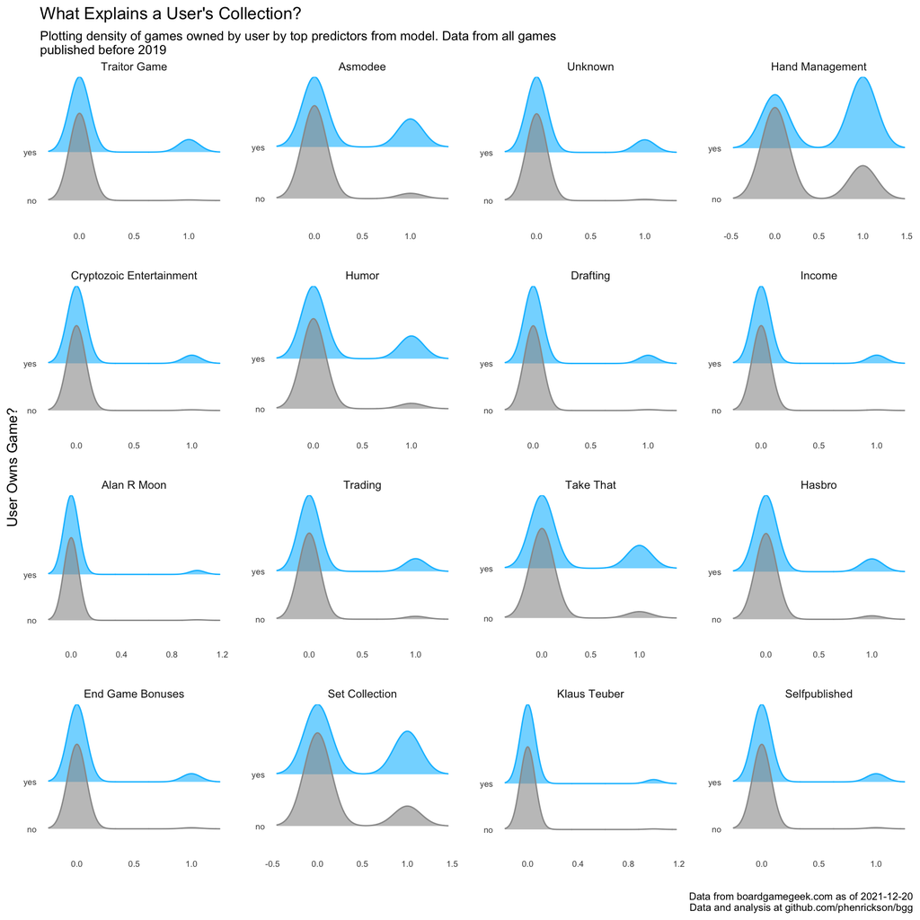

Binary predictors can be difficult to see with this visualization, so we can also directly examine the percentage of games in a user’s collection with a predictor vs the percentage of all games with that predictor.

| username | Feature | % of Games with Feature In_Collection | % of Games with Feature All_Games | Ratio |
| --- | --- | --- | --- | --- |
| PSwayze12 | Traitor Game | 14.3% | 0.6% | 22.1 |
| PSwayze12 | Income | 9.5% | 0.7% | 13.3 |
| PSwayze12 | Cryptozoic Entertainment | 9.5% | 0.8% | 11.6 |
| PSwayze12 | Unknown | 14.3% | 1.5% | 9.7 |
| PSwayze12 | Drafting | 9.5% | 1.0% | 9.2 |
| PSwayze12 | End Game Bonuses | 9.5% | 1.3% | 7.4 |
| PSwayze12 | Comic Book Strip | 9.5% | 1.4% | 7.0 |
| PSwayze12 | Mafia | 4.8% | 0.7% | 6.8 |
| PSwayze12 | Selfpublished | 9.5% | 1.4% | 6.7 |
| PSwayze12 | Asmodee | 28.6% | 5.4% | 5.3 |
| PSwayze12 | Trading | 14.3% | 3.2% | 4.5 |
| PSwayze12 | Role Playing | 14.3% | 3.2% | 4.5 |
| PSwayze12 | Humor | 23.8% | 5.6% | 4.3 |
| PSwayze12 | Hasbro | 14.3% | 3.9% | 3.7 |
| PSwayze12 | Take That | 23.8% | 6.6% | 3.6 |
| PSwayze12 | Horror | 14.3% | 3.9% | 3.6 |
| PSwayze12 | Word Game | 4.8% | 1.8% | 2.7 |
| PSwayze12 | Set Collection | 38.1% | 17.6% | 2.2 |
| PSwayze12 | Modular Board | 23.8% | 10.9% | 2.2 |
| PSwayze12 | Hand Management | 57.1% | 26.7% | 2.1 |
| PSwayze12 | Puzzle | 4.8% | 3.4% | 1.4 |
| PSwayze12 | Negotiation | 4.8% | 3.7% | 1.3 |
| PSwayze12 | Bluffing | 4.8% | 6.8% | 0.7 |
| PSwayze12 | Hidden Roles | 0.0% | 0.7% | 0.0 |
| PSwayze12 | Trivia | 0.0% | 1.8% | 0.0 |

# 3 Assess Model’s Performance on Training Set

Before predicting games in upcoming years, we can examine how well the model did and what games it liked in the training set. In this case, we used resampling techniques (cross validation) to ensure that the model had not seen a game before making its predictions.

## 3.1 Separation Plot

An easy way to examine the performance of classification model is to view a separation plot. We plot the predicted probabilities from the model for every game (from resampling) from lowest to highest. We then overlay a blue line for any game that the user does own. A good classifier is one that is able to *separate* the blue (games owned by the user) from the white (games not owned by the user), with most of the blue occurring at the highest probabilities (right side of the chart).

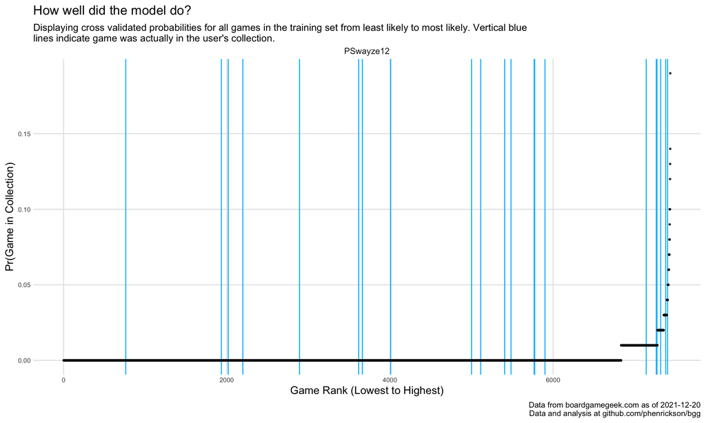

## 3.2 Top Games for **PSwayze12** from Training Set

We can display this information in table form, displaying the 100 games with the highest probability of ownership, adding a blue line when the user does own the game.

| username | yearpublished | game_id | name | pred_played | pred_own | actual_played | actual_own |
| --- | --- | --- | --- | --- | --- | --- | --- |
| PSwayze12 | 2016 | 72321 | The Networks | 0.19 | 0.19 | 0 | 0 |
| PSwayze12 | 2013 | 127024 | Room 25 | 0.08 | 0.14 | 0 | 0 |
| PSwayze12 | 2014 | 166384 | Spyfall | 0.14 | 0.13 | 0 | 0 |
| PSwayze12 | 2009 | 56885 | The Werewolves of Miller's Hollow: The Village | 0.03 | 0.12 | 0 | 0 |
| PSwayze12 | 2018 | 244711 | Newton | 0.01 | 0.10 | 0 | 0 |
| PSwayze12 | 2004 | 9220 | Saboteur | 0.12 | 0.10 | 0 | 0 |
| PSwayze12 | 2012 | 105551 | Archipelago | 0.14 | 0.10 | 0 | 0 |
| PSwayze12 | 2019 | 245655 | The King's Dilemma | 0.06 | 0.09 | 0 | 0 |
| PSwayze12 | 2015 | 175549 | Salem 1692 | 0.13 | 0.08 | 0 | 0 |
| PSwayze12 | 2018 | 225167 | Human Punishment: Social Deduction 2.0 | 0.06 | 0.08 | 0 | 0 |
| PSwayze12 | 2001 | 1927 | Munchkin | 0.02 | 0.08 | 0 | 0 |
| PSwayze12 | 2019 | 270971 | Era: Medieval Age | 0.04 | 0.07 | 0 | 0 |
| PSwayze12 | 2013 | 124548 | The Doom That Came to Atlantic City | 0.13 | 0.07 | 0 | 0 |
| PSwayze12 | 1933 | 1406 | Monopoly | 0.22 | 0.07 | 0 | 0 |
| PSwayze12 | 2018 | 256877 | Hail Hydra | 0.09 | 0.07 | 0 | 0 |
| PSwayze12 | 2016 | 205398 | Citadels | 0.08 | 0.07 | 0 | 0 |
| PSwayze12 | 1968 | 7262 | Top Trumps | 0.03 | 0.07 | 0 | 0 |
| PSwayze12 | 2017 | 228660 | Betrayal at Baldur's Gate | 0.07 | 0.06 | 0 | 0 |
| PSwayze12 | 2015 | 173200 | Epic Spell Wars of the Battle Wizards: Rumble at Castle Tentakill | 0.07 | 0.06 | 0 | 0 |
| PSwayze12 | 1959 | 7688 | Memory | 0.02 | 0.06 | 0 | 0 |
| PSwayze12 | 2016 | 188834 | Secret Hitler | 0.20 | 0.06 | 0 | 0 |
| PSwayze12 | 1999 | 47 | Chinatown | 0.05 | 0.06 | 0 | 0 |
| PSwayze12 | 2014 | 150376 | Dead of Winter: A Crossroads Game | 0.06 | 0.06 | 0 | 0 |
| PSwayze12 | 2018 | 247236 | Duelosaur Island | 0.02 | 0.05 | 0 | 0 |
| PSwayze12 | 2019 | 281259 | The Isle of Cats | 0.02 | 0.05 | 0 | 0 |
| PSwayze12 | 2018 | 199792 | Everdell | 0.05 | 0.05 | 0 | 0 |
| PSwayze12 | 2018 | 230769 | Who Goes There? | 0.05 | 0.05 | 0 | 0 |
| PSwayze12 | 2016 | 205716 | New Angeles | 0.02 | 0.05 | 0 | 0 |
| PSwayze12 | 1990 | 2944 | Halli Galli | 0.02 | 0.05 | 0 | 0 |
| PSwayze12 | 1986 | 925 | Werewolf | 0.06 | 0.05 | 0 | 0 |

[output cut: 70 more lines]

We can also more formally assess how well the model did in resampling by looking at the area under the receiver operating characteristic. A perfect model would receive a score of 1, while a model that cannot predict the outcome will default to a score of 0.5. The extent to which something is a *good* score depends on the setting, but generally anything in the .8 to .9 range is very good while the .7 to .8 range is perfectly acceptable.

| username | outcome_type | .metric | .estimator | .estimate |
| --- | --- | --- | --- | --- |
| PSwayze12 | own | roc_auc | binary | 0.650 |
| PSwayze12 | played | roc_auc | binary | 0.689 |

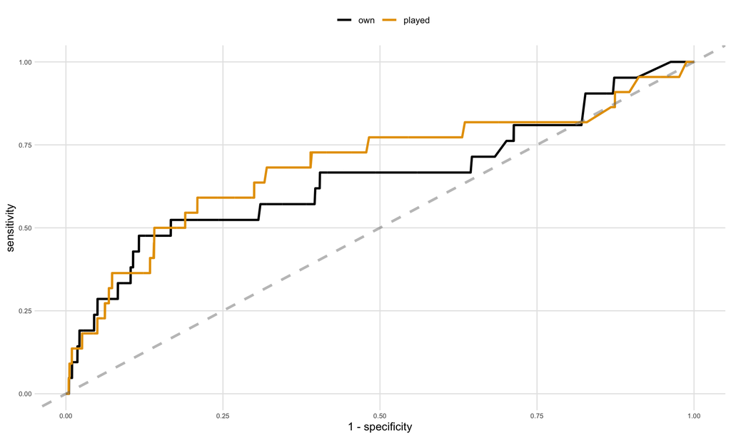

Another way to think about the model performance is to view its lift, or its ability to detect the positive outcomes over that of a null model. High lift indicates the model can much more quickly find all of the positive outcomes (in this case, games owned or played by the user), while a model with no lift is no better than random guessing.

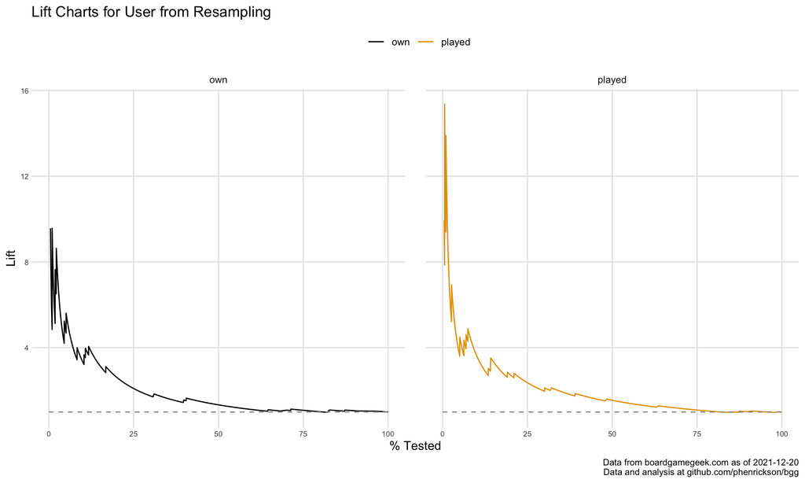

## 3.3 Most and Least Likely Games

What games does the model think PSwayze12 is **most likely to own** that are **not** in their collection?

| username | yearpublished | game_id | name | pred_own | actual_own |
| --- | --- | --- | --- | --- | --- |
| PSwayze12 | 2016 | 72321 | The Networks | 0.19 | 0 |
| PSwayze12 | 2013 | 127024 | Room 25 | 0.14 | 0 |
| PSwayze12 | 2014 | 166384 | Spyfall | 0.13 | 0 |
| PSwayze12 | 2009 | 56885 | The Werewolves of Miller's Hollow: The Village | 0.12 | 0 |
| PSwayze12 | 2018 | 244711 | Newton | 0.10 | 0 |

What games does the model think PSwayze12 is **least likely to own** that **are** in their collection?

| username | yearpublished | game_id | name | pred_own | actual_own |
| --- | --- | --- | --- | --- | --- |
| PSwayze12 | 1971 | 2392 | Mastermind | 0 | 1 |
| PSwayze12 | 2017 | 217466 | Mafiozoo | 0 | 1 |
| PSwayze12 | 2019 | 283393 | Aquatica | 0 | 1 |
| PSwayze12 | 2008 | 30549 | Pandemic | 0 | 1 |
| PSwayze12 | 1995 | 13 | Catan | 0 | 1 |

## 3.4 Top Games by Year

Top 25 games most likely to be owned by the user in each year, highlighting in blue the games that the user has owned/played.

| rank | 2011 | 2012 | 2013 | 2014 | 2015 | 2016 | 2017 | 2018 | 2019 |
| --- | --- | --- | --- | --- | --- | --- | --- | --- | --- |
| 1 | Panic Station | Archipelago | Room 25 | Spyfall | Salem 1692 | The Networks | Betrayal at Baldur's Gate | Newton | The King's Dilemma |
| 2 | Food Fight | Penny Arcade: The Game – Rumble in R'lyeh | The Doom That Came to Atlantic City | Dead of Winter: A Crossroads Game | Epic Spell Wars of the Battle Wizards: Rumble at Castle Tentakill | Citadels | The Thing: Infection at Outpost 31 | Human Punishment: Social Deduction 2.0 | Era: Medieval Age |
| 3 | Penny Arcade: The Game – Gamers vs. Evil | The Big Bang Theory: The Party Game | Batman: Arkham City Escape | La Granja | Blood Rage | Secret Hitler | Itchy Feet: the Travel Game | Hail Hydra | The Isle of Cats |
| 4 | Dark Moon | One Night Werewolf | Prosperity | Adventure Time Card Wars: Finn vs. Jake | Risk: Europe | New Angeles | Rick and Morty: Close Rick-Counters of the Rick Kind Deck-Building Game | Duelosaur Island | Crystal Palace |
| 5 | A Few Acres of Snow | Libertalia | Sushi Go! | Ultimate Werewolf | The Bloody Inn | Mansions of Madness: Second Edition | Unfair | Everdell | Yukon Airways |
| 6 | Space Empires: 4X | Locke & Key: The Game | The Hobbit: An Unexpected Journey | Hawken: Real-Time Card Game | One Night Ultimate Werewolf: Daybreak | Rick and Morty: Total Rickall Card Game | Bears vs Babies | Who Goes There? | Maracaibo |
| 7 | Saga | Hot Rod Creeps | Ultimate Werewolf: Inquisition | Adventure Time Card Wars: BMO vs. Lady Rainicorn | Homeland: The Game | Dead of Winter: The Long Night | Rick and Morty: Anatomy Park – The Game | The Walking Dead: No Sanctuary | The Menace Among Us |
| 8 | Takenoko | Terra Mystica | Crossing | DC Comics Deck-Building Game: Rivals – Batman vs The Joker | Grifters | Burke's Gambit | Gaia Project | Vengeance | Amul |
| 9 | Octopus's Garden | DC Comics Deck-Building Game | The Walking Dead Card Game | Imperial Settlers | Love Letter: The Hobbit – The Battle of the Five Armies | Inis | DC Comics Deck-Building Game: Confrontations | DC Spyfall | GROWL |
| 10 | The Walking Dead Board Game | Serenissima (Second Edition) | Spyrium | Ultimate Werewolf: Deluxe Edition | Ghostbusters: The Board Game | The Arrival | Harvest Dice | Betrayal Legacy | DC Deck-Building Game: Rebirth |
| 11 | The Road to Canterbury | Star Trek: Catan | The Lord of the Rings: The Fellowship of the Ring Deck-Building Game | Deception: Murder in Hong Kong | Love Letter: Batman | Master of Orion: The Board Game | Epic Spell Wars of the Battle Wizards: Melee at Murdershroom Marsh | Nemesis | Llamas Unleashed |
| 12 | Dixit: Odyssey | Seasons | Smash Up: Awesome Level 9000 | Don't Mess with Cthulhu | DC Comics Deck-Building Game: Teen Titans | Batman: The Animated Series Dice Game | One Night Ultimate Alien | Underwater Cities | Obscurio |
| 13 | Rory's Story Cubes: Voyages | 3012 | Smash Up: The Obligatory Cthulhu Set | One Night Ultimate Werewolf | Chaosmos | Timebomb | Werewords | One Week Ultimate Werewolf | Wingspan |
| 14 | Mundus Novus | Among the Stars | Berserk: War of the Realms | DC Comics Deck-Building Game: Heroes Unite | My Village | Sushi Go Party! | Pulsar 2849 | Ultimate Werewolf Legacy | Paris: La Cité de la Lumière |
| 15 | Creature Clash! Card Game | Crooks | The Walking Dead Board Game: The Best Defense | CapCom Street Fighter Deck-Building Game | Bastion | Spyfall 2 | Carthago: Merchants & Guilds | Werewords Deluxe Edition | Freshwater Fly |
| 16 | Rumble in the House | Munchkin Conan | The Red Dragon Inn 4 | The Lord of the Rings: The Return of the King Deck-Building Game | X-Men: Mutant Revolution | Time Bomb Evolution | Fallout | Cult: Choose Your God Wisely | Space Gate Odyssey |
| 17 | Airlines Europe | Fish Cook | Infamy | Smash Up: Science Fiction Double Feature | Catan: Traveler – Compact Edition | OrganATTACK! | Pendragon: The Fall of Roman Britain | Rick and Morty: The Pickle Rick Game | Key Market (Second Edition) |
| 18 | Québec | Dixit: Journey | Train Heist | Patchwork | Portal: The Uncooperative Cake Acquisition Game | Tempel des Schreckens | A Game of Thrones: Catan – Brotherhood of the Watch | Lords of Hellas | The Magnificent |
| 19 | Evo (Second Edition) | Pax Porfiriana | Gravwell: Escape from the 9th Dimension | Fields of Arle | Smash Up: Munchkin | 13 Days: The Cuban Missile Crisis | Pandemic Legacy: Season 2 | Catan Histories: Rise of the Inkas | Florenza Dice Game |
| 20 | Rolling Stock | Coup | Corto | Sons of Anarchy: Men of Mayhem | Barony | Roll Player | Sagrada | Gen7: A Crossroads Game | Call to Adventure |
| 21 | Infarkt | The Resistance: Avalon | Mush! Mush!: Snow Tails 2 | Deus | Baby Blues | Yokohama | Ticket to Ride: First Journey (Europe) | Fireball Island: The Curse of Vul-Kar | Sierra West |
| 22 | Band of Brothers: Screaming Eagles | Zug um Zug: Deutschland | Zombicide Season 2: Prison Outbreak | Five Tribes | Through the Ages: A New Story of Civilization | Hit Z Road | Pocket Mars | Gizmos | Old West Empresario |
| 23 | Sekigahara: The Unification of Japan | Gentlemen Thieves | Friese's Landlord | Relic Expedition | Grand Austria Hotel | Pandemic: Reign of Cthulhu | Gloomhaven | Century: Eastern Wonders | Minecraft: Builders & Biomes |
| 24 | Fighting Formations: Grossdeutschland Motorized Infantry Division | Kings of War | Superfight | North Wind | Love Letter: Adventure Time | Archer: Once You Go Blackmail... | Fast Forward: FORTRESS | Blue Lagoon | Azul: Summer Pavilion |
| 25 | No Retreat! The Russian Front | Mage Wars Arena | Ladies & Gentlemen | Abyss | The Voyages of Marco Polo | Capital Lux | Penguin Trap | Counterfeiters | Dizzle |

## 3.5 Interactive Predictions from Resampling

Interactive table for predictions from resampling.

|  | username | yearpublished | rank | game_id | name | pred_played | pred_own | actual_played | actual_own |
| --- | --- | --- | --- | --- | --- | --- | --- | --- | --- |
| 1 | PSwayze12 | 1900 | 39 | 10799 | Old Maid | 0.01 | 0.04 | 0 | 0 |
| 2 | PSwayze12 | 1900 | 43 | 2065 | Shogi | 0.01 | 0.03 | 0 | 0 |
| 3 | PSwayze12 | 1900 | 52 | 9851 | Shut the Box | 0.03 | 0.03 | 0 | 0 |
| 4 | PSwayze12 | 1900 | 71 | 45 | Perudo | 0.02 | 0.03 | 0 | 0 |
| 5 | PSwayze12 | 1900 | 73 | 1115 | Poker | 0.01 | 0.03 | 0 | 0 |
| 6 | PSwayze12 | 1900 | 82 | 2083 | Checkers | 0.01 | 0.02 | 0 | 0 |
| 7 | PSwayze12 | 1900 | 100 | 21389 | Happy Families | 0.02 | 0.02 | 0 | 0 |
| 8 | PSwayze12 | 1900 | 127 | 15878 | Rummy | 0.03 | 0.02 | 0 | 0 |
| 9 | PSwayze12 | 1900 | 159 | 11901 | Tic-Tac-Toe | 0.01 | 0.01 | 0 | 0 |
| 10 | PSwayze12 | 1900 | 161 | 188 | Go | 0.01 | 0.01 | 0 | 0 |

[output cut: 7426 more lines]

# 4 Validating the Model on 2020

How well did a model trained on a user’s collection through 2019 perform in predicting games for the user from 2020?

| username | outcome_type | yearpublished | .metric | .estimator | .estimate |
| --- | --- | --- | --- | --- | --- |
| PSwayze12 | own | 2020 | roc_auc | binary | 0.875 |
| PSwayze12 | played | 2020 | roc_auc | binary | 0.847 |

Table of top 25 games from 2020, highlighting games that the user owns.

| username | yearpublished | game_id | name | pred_own | pred_played | actual_own | actual_played |
| --- | --- | --- | --- | --- | --- | --- | --- |
| PSwayze12 | 2020 | 298352 | The Shining | 0.08 | 0.08 | 0 | 0 |
| PSwayze12 | 2020 | 184267 | On Mars | 0.07 | 0.08 | 0 | 0 |
| PSwayze12 | 2020 | 296892 | Sacred Rites | 0.04 | 0.06 | 0 | 0 |
| PSwayze12 | 2020 | 287507 | Evil Dead 2: The Board Game | 0.03 | 0.03 | 0 | 0 |
| PSwayze12 | 2020 | 301662 | Epic Spell Wars of the Battle Wizards: Hijinx at Hell High | 0.03 | 0.03 | 0 | 0 |
| PSwayze12 | 2020 | 302809 | Betrayal at Mystery Mansion | 0.03 | 0.03 | 0 | 0 |
| PSwayze12 | 2020 | 304434 | Victim: The Cursed Forest | 0.03 | 0.03 | 0 | 0 |
| PSwayze12 | 2020 | 313817 | Hello Neighbor: The Secret Neighbor Party Game | 0.03 | 0.03 | 0 | 0 |
| PSwayze12 | 2020 | 256317 | Guild Master | 0.02 | 0.02 | 0 | 0 |
| PSwayze12 | 2020 | 297030 | Tekhenu: Obelisk of the Sun | 0.02 | 0.03 | 0 | 0 |
| PSwayze12 | 2020 | 300322 | Hallertau | 0.02 | 0.02 | 0 | 0 |
| PSwayze12 | 2020 | 302465 | Obsidia | 0.02 | 0.02 | 0 | 0 |
| PSwayze12 | 2020 | 307997 | Insider Black | 0.02 | 0.02 | 0 | 0 |
| PSwayze12 | 2020 | 316377 | 7 Wonders (Second Edition) | 0.02 | 0.02 | 0 | 0 |
| PSwayze12 | 2020 | 320819 | Dinner in Paris | 0.02 | 0.02 | 0 | 0 |
| PSwayze12 | 2020 | 217990 | Stellar Horizons | 0.01 | 0.01 | 0 | 0 |
| PSwayze12 | 2020 | 246900 | Eclipse: Second Dawn for the Galaxy | 0.01 | 0.01 | 0 | 0 |
| PSwayze12 | 2020 | 257001 | Munchkin Dungeon | 0.01 | 0.01 | 0 | 0 |
| PSwayze12 | 2020 | 267009 | Rome & Roll | 0.01 | 0.01 | 0 | 0 |
| PSwayze12 | 2020 | 270685 | Capone: The Business of Prohibition | 0.01 | 0.00 | 0 | 0 |
| PSwayze12 | 2020 | 271002 | Myraclia | 0.01 | 0.01 | 0 | 0 |
| PSwayze12 | 2020 | 282171 | Trial by Trolley | 0.01 | 0.01 | 0 | 0 |
| PSwayze12 | 2020 | 287088 | Block Happy | 0.01 | 0.01 | 0 | 0 |
| PSwayze12 | 2020 | 288068 | Steven Universe: Beach-A-Palooza Card Battling Game | 0.01 | 0.01 | 0 | 0 |
| PSwayze12 | 2020 | 291457 | Gloomhaven: Jaws of the Lion | 0.01 | 0.01 | 0 | 0 |

# 5 Predicting Upcoming Games (2020 and On) for **PSwayze12**

Examine the top games for the test set.

| username | yearpublished | game_id | name | rank | own | played |
| --- | --- | --- | --- | --- | --- | --- |
| PSwayze12 | 2020 | 298352 | The Shining | 1 | 0.08 | 0.08 |
| PSwayze12 | 2020 | 184267 | On Mars | 2 | 0.07 | 0.08 |
| PSwayze12 | 2020 | 296892 | Sacred Rites | 3 | 0.04 | 0.06 |
| PSwayze12 | 2020 | 287507 | Evil Dead 2: The Board Game | 4 | 0.03 | 0.03 |
| PSwayze12 | 2020 | 301662 | Epic Spell Wars of the Battle Wizards: Hijinx at Hell High | 5 | 0.03 | 0.03 |
| PSwayze12 | 2020 | 313817 | Hello Neighbor: The Secret Neighbor Party Game | 6 | 0.03 | 0.03 |
| PSwayze12 | 2020 | 302809 | Betrayal at Mystery Mansion | 7 | 0.03 | 0.03 |
| PSwayze12 | 2020 | 304434 | Victim: The Cursed Forest | 8 | 0.03 | 0.03 |
| PSwayze12 | 2020 | 307997 | Insider Black | 9 | 0.02 | 0.02 |
| PSwayze12 | 2020 | 300322 | Hallertau | 10 | 0.02 | 0.02 |
| PSwayze12 | 2020 | 302465 | Obsidia | 11 | 0.02 | 0.02 |
| PSwayze12 | 2020 | 320819 | Dinner in Paris | 12 | 0.02 | 0.02 |
| PSwayze12 | 2020 | 297030 | Tekhenu: Obelisk of the Sun | 13 | 0.02 | 0.03 |
| PSwayze12 | 2020 | 256317 | Guild Master | 14 | 0.02 | 0.02 |
| PSwayze12 | 2020 | 316377 | 7 Wonders (Second Edition) | 15 | 0.02 | 0.02 |
| PSwayze12 | 2020 | 298130 | Amalfi | 16 | 0.01 | 0.00 |
| PSwayze12 | 2020 | 317231 | Monasterium | 17 | 0.01 | 0.00 |
| PSwayze12 | 2020 | 296151 | Viscounts of the West Kingdom | 18 | 0.01 | 0.01 |
| PSwayze12 | 2020 | 270685 | Capone: The Business of Prohibition | 19 | 0.01 | 0.00 |
| PSwayze12 | 2020 | 267009 | Rome & Roll | 20 | 0.01 | 0.01 |
| PSwayze12 | 2020 | 292971 | Ettin | 21 | 0.01 | 0.01 |
| PSwayze12 | 2020 | 327371 | Psycho Killer | 22 | 0.01 | 0.01 |
| PSwayze12 | 2020 | 299169 | Spicy | 23 | 0.01 | 0.00 |
| PSwayze12 | 2020 | 298638 | Sheriff of Nottingham (2nd Edition) | 24 | 0.01 | 0.01 |
| PSwayze12 | 2020 | 311829 | The Arctic | 25 | 0.01 | 0.01 |
| PSwayze12 | 2021 | 291847 | Mantis Falls | 1 | 0.18 | 0.16 |
| PSwayze12 | 2021 | 331635 | Kameloot | 2 | 0.08 | 0.08 |
| PSwayze12 | 2021 | 340466 | Unfathomable | 3 | 0.08 | 0.09 |
| PSwayze12 | 2021 | 318322 | Hidden Strike: American Revolution | 4 | 0.04 | 0.04 |
| PSwayze12 | 2021 | 302755 | Stop the Train! | 5 | 0.04 | 0.03 |
| PSwayze12 | 2021 | 313085 | Sleep Tight | 6 | 0.04 | 0.03 |
| PSwayze12 | 2021 | 318474 | Who Goes There? 2nd Edition | 7 | 0.03 | 0.03 |
| PSwayze12 | 2021 | 320446 | Corduba 27 a.C. | 8 | 0.02 | 0.01 |
| PSwayze12 | 2021 | 316287 | Quest | 9 | 0.02 | 0.02 |
| PSwayze12 | 2021 | 310100 | Nemesis: Lockdown | 10 | 0.02 | 0.02 |
| PSwayze12 | 2021 | 291859 | Riftforce | 11 | 0.02 | 0.02 |
| PSwayze12 | 2021 | 298383 | Golem | 12 | 0.02 | 0.02 |
| PSwayze12 | 2021 | 342942 | Ark Nova | 13 | 0.02 | 0.02 |
| PSwayze12 | 2021 | 319999 | Dungeon Decorators | 14 | 0.02 | 0.02 |
| PSwayze12 | 2021 | 275213 | 7 Summits | 15 | 0.01 | 0.01 |
| PSwayze12 | 2021 | 316090 | Vivid Memories | 16 | 0.01 | 0.01 |
| PSwayze12 | 2021 | 329670 | Pandemic: Hot Zone – Europe | 17 | 0.01 | 0.01 |
| PSwayze12 | 2021 | 341256 | Murano: Light Masters | 18 | 0.01 | 0.01 |
| PSwayze12 | 2021 | 276856 | Ruination | 19 | 0.01 | 0.01 |
| PSwayze12 | 2021 | 293404 | Public Market | 20 | 0.01 | 0.01 |
| PSwayze12 | 2021 | 301441 | Drawn to Adventure | 21 | 0.01 | 0.01 |
| PSwayze12 | 2021 | 316786 | Tabannusi: Builders of Ur | 22 | 0.01 | 0.01 |
| PSwayze12 | 2021 | 322588 | Origins: First Builders | 23 | 0.01 | 0.01 |
| PSwayze12 | 2021 | 277469 | The Phantom: The Card Game | 24 | 0.01 | 0.00 |
| PSwayze12 | 2021 | 318996 | Welcome to Sysifus Corp | 25 | 0.01 | 0.01 |
| PSwayze12 | 2022 | 317511 | Tindaya | 1 | 0.05 | 0.05 |
| PSwayze12 | 2022 | 283137 | Human Punishment: The Beginning | 2 | 0.03 | 0.03 |
| PSwayze12 | 2022 | 305096 | Endless Winter: Paleoamericans | 3 | 0.01 | 0.01 |
| PSwayze12 | 2022 | 339592 | Sheep in Disguise | 4 | 0.01 | 0.01 |
| PSwayze12 | 2022 | 330950 | Age of Galaxy | 5 | 0.01 | 0.01 |
| PSwayze12 | 2022 | 334065 | Verdant | 6 | 0.01 | 0.01 |
| PSwayze12 | 2022 | 284189 | Foundations of Rome | 7 | 0.01 | 0.01 |
| PSwayze12 | 2022 | 331106 | The Witcher: Old World | 8 | 0.01 | 0.01 |
| PSwayze12 | 2022 | 324090 | Scarface 1920 | 9 | 0.01 | 0.01 |
| PSwayze12 | 2022 | 342246 | Feuding Foodies | 10 | 0.01 | 0.01 |
| PSwayze12 | 2022 | 295895 | Distilled | 11 | 0.01 | 0.01 |
| PSwayze12 | 2022 | 293941 | Mage Noir | 12 | 0.01 | 0.02 |
| PSwayze12 | 2022 | 316624 | Stationfall | 13 | 0.00 | 0.00 |
| PSwayze12 | 2022 | 240980 | Blood on the Clocktower | 14 | 0.00 | 0.00 |
| PSwayze12 | 2022 | 271601 | Feed the Kraken | 15 | 0.00 | 0.00 |
| PSwayze12 | 2022 | 155250 | TseuQuesT | 16 | 0.00 | 0.00 |
| PSwayze12 | 2022 | 258779 | Planet Unknown | 17 | 0.00 | 0.00 |
| PSwayze12 | 2022 | 270871 | Agemonia | 18 | 0.00 | 0.00 |
| PSwayze12 | 2022 | 253759 | Paint the Roses | 19 | 0.00 | 0.00 |
| PSwayze12 | 2022 | 322564 | Fjords | 20 | 0.00 | 0.00 |
| PSwayze12 | 2022 | 242705 | Aeon Trespass: Odyssey | 21 | 0.00 | 0.00 |
| PSwayze12 | 2022 | 266592 | TacTiki | 22 | 0.00 | 0.00 |
| PSwayze12 | 2022 | 293547 | Reload | 23 | 0.00 | 0.00 |
| PSwayze12 | 2022 | 327711 | It's a Wonderful Kingdom | 24 | 0.00 | 0.00 |
| PSwayze12 | 2022 | 338067 | 6: Siege – The Board Game | 25 | 0.00 | 0.00 |

## 5.1 Interactive Table for Upcoming Games 2020 and On

|  | username | yearpublished | game_id | name | rank | own | played |
| --- | --- | --- | --- | --- | --- | --- | --- |
| 1 | PSwayze12 | 2021 | 291847 | Mantis Falls | 1 | 0.18 | 0.16 |
| 2 | PSwayze12 | 2021 | 331635 | Kameloot | 2 | 0.08 | 0.08 |
| 3 | PSwayze12 | 2021 | 340466 | Unfathomable | 3 | 0.08 | 0.09 |
| 4 | PSwayze12 | 2020 | 298352 | The Shining | 4 | 0.08 | 0.08 |
| 5 | PSwayze12 | 2020 | 184267 | On Mars | 5 | 0.07 | 0.08 |
| 6 | PSwayze12 | 2022 | 317511 | Tindaya | 6 | 0.05 | 0.05 |
| 7 | PSwayze12 | 2021 | 318322 | Hidden Strike: American Revolution | 7 | 0.04 | 0.04 |
| 8 | PSwayze12 | 2021 | 302755 | Stop the Train! | 8 | 0.04 | 0.03 |
| 9 | PSwayze12 | 2020 | 296892 | Sacred Rites | 9 | 0.04 | 0.06 |
| 10 | PSwayze12 | 2021 | 313085 | Sleep Tight | 10 | 0.04 | 0.03 |

[output cut: 1627 more lines]